# R 신경망

Jang, Eunhee

2018년 6월 7일

#### 신경망이란?

> 블랙박스 프로세스로 뉴론, 뇌구조를 모방하여 임의의 기능을 모델링한다.

### 목차

#### 2. 활성화 함수

활성화 함수? 입력신호의 총합이 활성화를 일으킬지 정하는 역할을 하는 함수

```
k = x0*w2 + x1*w2 + x2*w2
y = f(k)
1: 신호가 흐른다.
2. 신호가 안흐른다.
```

- 활성화 함수의 종류
1. 계단함수: 입력신호의 합이 임계치를 넘느냐 안넘느냐에 따라 0과 1을 리턴

```r
step <- function(x) {ifelse(x>=0,1,0)}

step(-0.1)
```

```
## [1] 0
```

```r
step(1.1)
```

```
## [1] 1
```

```r
x <- seq(-5,5,0.01)
head(x)
```

```
## [1] -5.00 -4.99 -4.98 -4.97 -4.96 -4.95
```

```r
head(step(x))
```

```
## [1] 0 0 0 0 0 0
```

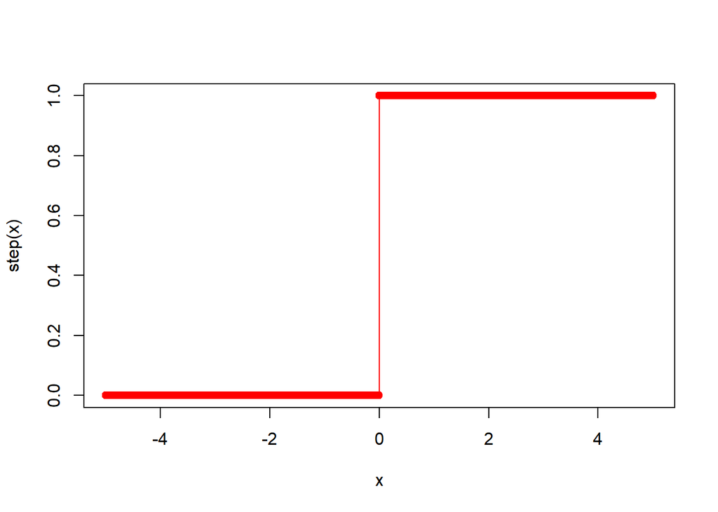

```r
plot(x,step(x),col ="red",type = 'o')
```

2. 시그모이드(Sigmoid) 함수: 연속적인 실수를 리턴한다. 단층 : 입력층 –> 출력층 다층 : 입력층 –> 은닉층 –> 출력층

단층이 아니라 다층 신경망을 사용하게 되면 활성화 함수를 시그모이드 함수를 사용해야한다. because: 계단형은 기울기가 0이기때문에 미분이 불가능, 역전파시 W갱신을 미분하여 계산한다.

```
               1
f(k) = ------------------
          1 + exp(-k)
```

```r
sigmoid <- function(x){ 1 / (1+exp(-x))}
sigmoid(1.0)
```

```
## [1] 0.7310586
```

```r
sigmoid(2.0)
```

```
## [1] 0.8807971
```

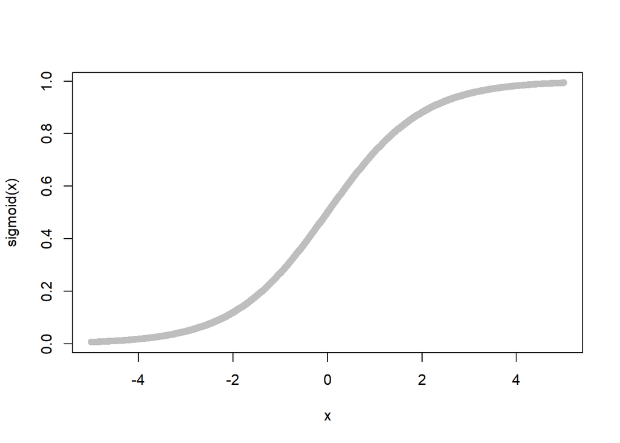

```r
plot(x,sigmoid(x),col="gray")
```

3. ReLu(Rectified Linear Unit) 함수  
   sigmoid함수는 단점이 기울기 0이 되는 부분때문에 학습이 느린 단점이 있다.  
   ReLu는 입력이 0을 넘으면 그 입력을 그대로 출력하고 0 이하면 0을 출력하는 함수  
   오래전부터 신경망은 시그모이드 함수를 사용해왔으나 최근에는 ReLu함수를 주로 이용한다.

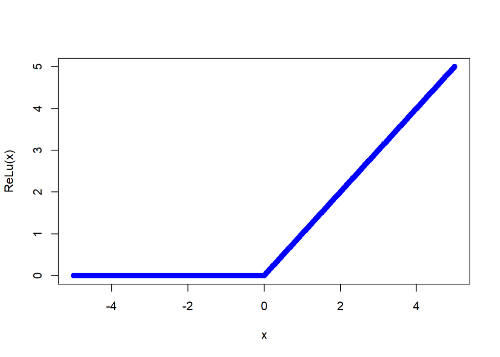

```r
ReLu <- function(x) {ifelse(x>0,x,0)}

plot(x,ReLu(x),col ="blue")
```

#### 실습1. 콘크리트 데이터

콘크리트의 강도를 예측하는 신경망을 만드는 실습  
자갈, 모래, 시멘트 등을 몇대 몇 비율로 섞었을때 어느정도 강도가 나오는지 예측하는 신경망  
1. mount of cement: 콘크리트의 총량 2. slag : 시멘트 3. ash : 분 (시멘트) 4. water : 물 5. superplasticizer : 고성능 감수재(콘크리트 강도를 높이는 첨가제) 6. coarse aggregate : 굵은 자갈 7. fine aggregate : 잔 자갈 8. aging time : 숙성시간 9. strength : 강도

```r
# 1. data load
con <- read.csv("C:/data/concrete.csv", header = T)

head(con)
```

```
##   cement  slag   ash water superplastic coarseagg fineagg age strength
## 1  141.3 212.0   0.0 203.5          0.0     971.8   748.5  28    29.89
## 2  168.9  42.2 124.3 158.3         10.8    1080.8   796.2  14    23.51
## 3  250.0   0.0  95.7 187.4          5.5     956.9   861.2  28    29.22
## 4  266.0 114.0   0.0 228.0          0.0     932.0   670.0  28    45.85
## 5  154.8 183.4   0.0 193.3          9.1    1047.4   696.7  28    18.29
## 6  255.0   0.0   0.0 192.0          0.0     889.8   945.0  90    21.86
```

```r
# 2. normalization
normalize <- function(x) {
  return ( (x-min(x)) / (max(x) - min(x)) )
}

con_no <- as.data.frame(lapply(con,normalize))

#정규화한 데이터와 원본데이터 비교
summary(con_no$strength)
```

```
##    Min. 1st Qu.  Median    Mean 3rd Qu.    Max.
##  0.0000  0.2664  0.4001  0.4172  0.5457  1.0000
```

```r
summary(con$strength)
```

```
##    Min. 1st Qu.  Median    Mean 3rd Qu.    Max.
##    2.33   23.71   34.45   35.82   46.13   82.60
```

```r
# 3. trainin데이터, test데이터 나눈다.

div <- round(nrow(con_no) * 0.75)
con_train <- con_no[1:div,]
con_test <- con_no[(div+1):nrow(con),]

# 4. neuralnet 패키지를 설치한다.
# install.packages("neuralnet")
library(neuralnet)

# 5. 모델(신경망) 생성하기
attach(con_train)
con_model <- neuralnet(formula=strength ~ cement + slag + ash  +water +superplastic + coarseagg  + fineagg  + age, data =con_train)

# 6. 모델 시각화
plot(con_model)

# 7. 테스트 데이터로 모델성능 테스트
ncol <- which(colnames(con_test) == "strength")
model_result <- compute(con_model, con_test[-ncol])

predict_strength <- model_result$net.result
summary(model_result$net.result)
```

```
##        V1
##  Min.   :0.06177111
##  1st Qu.:0.27482166
##  Median :0.45691058
##  Mean   :0.42696965
##  3rd Qu.:0.57107527
##  Max.   :0.67312717
```

```r
# 8. 예측값과 실제값간의 상관관계 확인
cor(model_result$net.result, con_test$strength)
```

```
##            [,1]
## [1,] 0.80573033
```

```r
# 9. 모델성능개선
con_model1 <- neuralnet(formula=strength ~ cement + slag + ash + water +superplastic + coarseagg  + fineagg  + age, data =con_train, hidden = c(5,2))

model_result1 <- compute(con_model1, con_test[-ncol])

predict_strength1 <- model_result1$net.result
summary(model_result1$net.result)
```

```
##        V1
##  Min.   :0.07139277
##  1st Qu.:0.27685899
##  Median :0.41346921
##  Mean   :0.42344883
##  3rd Qu.:0.55896517
##  Max.   :0.96128452
```

```r
summary(con_test$strength)
```

```
##       Min.    1st Qu.     Median       Mean    3rd Qu.       Max.
## 0.03052199 0.26775258 0.41030273 0.42254774 0.53120718 1.00000000
```

```r
cor(predict_strength1, con_test$strength)
```

```
##              [,1]
## [1,] 0.9316421367
```

#### 실습2. 회귀분석 시 사용한 wine data로 ANN

```r
# 1. data load
wine <- read.csv("C:/data/whitewines.csv", header = T)

head(wine)
```

```
##   fixed.acidity volatile.acidity citric.acid residual.sugar chlorides
## 1           6.7             0.62        0.24           1.10     0.039
## 2           5.7             0.22        0.20          16.00     0.044
## 3           5.9             0.19        0.26           7.40     0.034
## 4           5.3             0.47        0.10           1.30     0.036
## 5           6.4             0.29        0.21           9.65     0.041
## 6           7.0             0.14        0.41           0.90     0.037
##   free.sulfur.dioxide total.sulfur.dioxide density   pH sulphates
## 1                   6                   62 0.99340 3.41      0.32
## 2                  41                  113 0.99862 3.22      0.46
## 3                  33                  123 0.99500 3.49      0.42
## 4                  11                   74 0.99082 3.48      0.54
## 5                  36                  119 0.99334 2.99      0.34
## 6                  22                   95 0.99140 3.25      0.43
##       alcohol quality
## 1 10.40000000       5
## 2  8.90000000       6
## 3 10.10000000       6
## 4 11.20000000       4
## 5 10.93333333       6
## 6 10.90000000       6
```

```r
# 2. normalization
normalize <- function(x) {
  return ( (x-min(x)) / (max(x) - min(x)) )
}

wine_no <- as.data.frame(lapply(wine,normalize))

#정규화한 데이터와 원본데이터 비교
summary(wine_no$quality)
```

```
##      Min.   1st Qu.    Median      Mean   3rd Qu.      Max.
## 0.0000000 0.3333333 0.5000000 0.4796516 0.5000000 1.0000000
```

```r
summary(wine$quality)
```

```
##     Min.  1st Qu.   Median     Mean  3rd Qu.     Max.
## 3.000000 5.000000 6.000000 5.877909 6.000000 9.000000
```

```r
# 3. trainin데이터, test데이터 나눈다.

div <- round(nrow(wine_no) * 0.75)
wine_train <- wine_no[1:div,]
wine_test <- wine_no[(div+1):nrow(wine_no),]

# 4. neuralnet 패키지를 설치한다.
# install.packages("neuralnet")
library(neuralnet)

# 5. 모델(신경망) 생성하기
attach(wine_train)
wine_model <- neuralnet(formula= quality ~ fixed.acidity + volatile.acidity + citric.acid + residual.sugar + chlorides + free.sulfur.dioxide + total.sulfur.dioxide + density + pH + sulphates + alcohol, data =wine_train)

# 6. 모델 시각화
plot(wine_model)

# 7. 테스트 데이터로 모델성능 테스트
ncol <- which(colnames(wine_test) == "quality")
wine_mresult <- compute(wine_model, wine_test[-ncol])

predict_strength <- wine_mresult$net.result
summary(wine_mresult$net.result)
```

```
##        V1
##  Min.   :0.2359992
##  1st Qu.:0.4186111
##  Median :0.4722905
##  Mean   :0.4759002
##  3rd Qu.:0.5353439
##  Max.   :0.6691352
```

```r
# 8. 예측값과 실제값간의 상관관계 확인
cor(predict_strength, wine_test$quality)
```

```
##              [,1]
## [1,] 0.5656728135
```

```r
# 9. 모델성능개선
wine_model1 <- neuralnet(formula=quality ~ fixed.acidity + volatile.acidity + citric.acid + residual.sugar + chlorides + free.sulfur.dioxide + total.sulfur.dioxide + density + pH + sulphates + alcohol, data =wine_train, hidden = c(5,2))

plot(wine_model1)

wine_model_result1 <- compute(wine_model1, wine_test[-ncol])

predict_strength1 <- wine_model_result1$net.result
summary(wine_model_result1$net.result)
```

```
##        V1
##  Min.   :0.1195566
##  1st Qu.:0.4072666
##  Median :0.4750024
##  Mean   :0.4791492
##  3rd Qu.:0.5481627
##  Max.   :0.8584300
```

```r
summary(wine_test$quality)
```

```
##      Min.   1st Qu.    Median      Mean   3rd Qu.      Max.
## 0.0000000 0.3333333 0.5000000 0.4829793 0.5000000 1.0000000
```

```r
cor(predict_strength1, wine_test$quality)
```

```
##              [,1]
## [1,] 0.6300622277
```

#### 자동화 스크립트 완성하기

```r
my_r_func <- function() {
  rm()
  y <- " ######################################################### \n # 1. 막대그래프              11. Decision Tree 머신러닝 \n # 2. 원형그래프              12. 규칙기반 oneR/Jriper        \n # 3. 산포도 그래프          13. 단순 회귀        \n # 4. 워드 클라우드                          # 14. 신경망(ANN)                                    \n # 5. 사분위수 그래프                                    \n # 6. 분산과 표준편차                                    \n # 7. 정규분포와 히스토그램                              \n # 8. 산포도와 회귀직선                                  \n # 9. knn 머신러닝                                       \n # 10. naive bayes 머신러닝                              \n ######################################################### "
  cat(y)

  ########### 1. 패키지 설치
  # 현재 컴퓨터에 필요한 패키지 설치
  # 만약 패키지가 존재하지 않는 경우에만 설치

  packages <- c("XML","stringr","rJava","KoNLP","wordcloud","lubridate","data.table","e1071","plyr","outliers","FSelector","gmodels","fBasics","fBasics","class","rpart","stats","RWeka")

  if (length(setdiff(packages, rownames(installed.packages()))) > 0) {
    install.packages(setdiff(packages, rownames(installed.packages())))
  }

  library(data.table)
  # x3 <- menu( c("막대그래프", "원형그래프", "산포도 그래프", "워드 클라우드", "사분위수 그래프", "분산과 표준편차","정규분포와 히스토그램","산포도와 회귀직선"
  #               "knn 머신러닝", "naive bayes 머신러닝","Decision Tree 머신러닝","규칙기반 oneR/Jriper","단순 회귀") ,
  #             title ='원하는 그래프를 선택하세요 ', graphics=T)
  x3 <- as.numeric(readline(prompt = "원하는 그래프를 선택하세요"))
  switch(x3,
         barchart={
           table <- get(readline(prompt = "테이블을 입력하세요~ "))
           x  <- menu( colnames(table) , title ='sum할 컬럼명(number)을 입력하세요 ')
           x1 <- menu( colnames(table) , title ='기준이될 컬럼명을 입력하세요 ')
           x2 <- menu( colnames(table) , title ='그루핑할 컬럼을 입력하세요 ')
           y <- tapply(table[, x], list(table[,x2], table[,x1]), sum)
           y[is.na(y)] <- 0

           barplot(y, col = rainbow(length(y)), beside = T)
           legend("topright", fill = rainbow(14), legend = rownames(y))

         },
         piechart={
           table <- get(readline(prompt = "테이블을 입력하세요~ "))
           x  <- menu( colnames(table) , title ='sum할 컬럼명(number)을 입력하세요 ')
           x1 <- menu( colnames(table) , title ='기준이될 컬럼명을 입력하세요 ')

           z <- tapply(table[,x], table[,x1], sum)

           rate <- round( z / sum(table[,x]) * 100, 1)
           pie(z, col= rainbow(length(names(z))), main = "Salary Pie Chart",
               labels = paste(names(z), rate,'%'))

         },
         plot = {
           table <- get(readline(prompt = "테이블을 입력하세요~ "))
           x1 <- menu(colnames(table) , title ='x축이될 컬럼명을 입력하세요 ')
           x2 <- menu(colnames(table) , title ='y축이될 컬럼명을 입력하세요 ')

           plot(table[,x1], table[,x2], xlab = colnames(table[x1]),
                ylab = colnames(table[x2]), pch = '★', col ='Violet')
         },
         wordcloud = {
           data <- file.choose()
           file <- readLines(data)

           library(KoNLP)
           library(wordcloud)
           library(plyr)

           useSejongDic()
           nouns <- sapply(file, extractNoun, USE.NAMES = F)

           nouns <- unlist(nouns)
           # data 형식을 vector로 바꿈

           nouns <- nouns[nchar(nouns)>= 2]

           cnouns <- count(nouns)

           pal <- brewer.pal(6,"Dark2")

           pal <- pal[-(1)]

           x11()

           wordcloud(words=cnouns$x, freq=cnouns$freq, colors=pal, min.freq=5,
                     random.order=F)
         },
         boxplot = {
           table <- get(readline(prompt = "테이블명을 입력하세요~ "))
           x  <- menu( colnames(table) , title ='컬럼명을 입력하세요 ')

           boxplot(table[,x], horizontal = T)
         },
         var = {
           table <- get(readline(prompt = "분산을 시각화할 테이블명을 입력하시오 "))
           col <- menu(colnames(table), title = '분산을 시각화할 컬럼을 선택하세요.')
           x <- table[,col]
           cnt <- length(x)
           plot( x, main = paste("분산 =", round(var(x),3), "표준편차 =", round(sd(x),3)),
                 col = "Navy Blue",ylab = colnames(table[col]))
           lines(rep(mean(x),cnt), type = "l", col = "Violet Red")
         },
         hist = {
           table <- get(readline(prompt = "정규분포 곡선을 그릴 테이블 명을 입력하세요 "))
           col <- menu(colnames(table), title = "정규분포곡선을 그릴 컬럼명을 입력하세요 ")

           col <- table[order(table[col], decreasing = F), col]

           hist(col, col = topo.colors(8, alpha=0.7),ann = FALSE)
           par(new = T)
           plot(col, dnorm(col, mean = mean(col), sd = sd(col)), type = "l",
                main = paste(round(skewness(col),3),"정규분포 그래프"),ylab = "도수",
                axes = FALSE)
         },
         plot2 = {
           table_name <- readline(prompt = "산포도 그래프를 그릴 테이블 명을 입력하세요 ")
           table <- get(table_name)
           x_axis <- menu(colnames(table), title = "x 축 데이터를 입력하세요 ")
           y_axis <- menu(colnames(table), title = "y 축 데이터를 입력하세요 ")

           plot(table[,x_axis], table[,y_axis], main = paste(table_name, "산포도그래프"),
                xlab = colnames(table[x_axis]), ylab = colnames(table[y_axis]))
           model<- lm(table[,y_axis]~table[,x_axis])
           abline(model,col='red')
         },
         knn = {

           setwd("C:/data")
           #
           # data <- readline("분석할 csv파일명을 입력하세요 ")
           #
           print("분석할 csv파일명을 입력하세요")
           data<-file.choose()

           table1 <- na.omit(read.csv(data, stringsAsFactors = FALSE))

           col <- menu(colnames(table1), title = "라벨이 될 컬럼 이름을 입력하세요 ")

           col_n <- menu(colnames(table1), title = "제거할 컬럼 이름을 입력하세요 ")

           # colname으로 받아야함
           col1 <- colnames(table1)[col]

           normalize <- function(x) {
             return( (x-min(x))/ ( max(x)-min(x)))
           }

           # 불필요한 컬럼 삭제하기
           table1 <- table1[-col_n]

           # which : column이 위치한 숫자가 출력
           ncol <- which(colnames(table1) == col1)

           # 정규화
           table_n <- as.data.frame(lapply(table1[, -ncol],normalize))
```

```r
           # z_score 표준화로 대체 사용가능
           # table_z <- as.data.frame(scale(table1[-ncol]))

           # training data 와 test data 바꾸기
           mm<-round(nrow(table_n) * 9/10)

           table_train <- table_n[1:mm, ]
           table_test  <- table_n[(mm+1):nrow(table_n), ]

           table_train_label <- table1[1:mm, col1]
           table_test_label  <- table1[(mm+1):nrow(table_n), col1]


           # k 값 자동 생성

           library(caret)

           library(e1071)

           repeats = 20

           numbers = 10

           tunel = 10

           # "데이터가 부정확, 불완전 또는 불합리한가 어떤가를 확인하기 위해서 사용되는 처리"
           set.seed(1234)
           x = trainControl(method = "repeatedcv",

                            number = numbers,

                            repeats = repeats,

                            classProbs = TRUE,

                            summaryFunction = twoClassSummary)


           # normalize에서 label이 사라짐 -> cbind로 묶음

           model1 <- train(label~. , data = cbind(label = table_train_label, table_train), method = "knn",

                           preProcess = c("center","scale"),

                           trControl = x,

                           metric = "ROC",

                           tuneLength = tunel)



           # Summary of model
           k_n <- max(model1$bestTune)


           # knn 알고리즘
           library(class)

           result1 <- knn(train=table_train, test=table_test, cl= table_train_label, k = k_n )

           # 확률구하기
           prop.table( table(ifelse(table1[(mm+1):nrow(table_n), col1]==result1,"o","x" )))

           # 이원교차표
           library(gmodels)

           CrossTable( x= table_test_label, y= result1, prop.chisq=FALSE)



           # 예측할 환자정보
           print("예측할 환자정보를 입력하세요.")
           patient <- file.choose()
           table2 <- na.omit(read.csv(patient))


           # rbind 해서 normalize하면 안됨. 트레이닝은 전체 테이터로만 해야 함.
           col2 <- colnames(table2)[col]

           table2 <- table2[-col_n]

           # print(table2)
           ncol <- which(colnames(table2) == col2)
           table_test2 <- table2[,-ncol]
           table_test2 <- normalize(table_test2)

           # print(table_test2)

           result2 <- knn(train=table_train, test = table_test2, cl= table_train_label, k = k_n )

           return(paste(result2,"(으)로 예측됩니다"))
         },
         naive_bayes = {

           setwd("C:/data")

           print("분석할 csv파일명을 입력하세요 ")
           data<-file.choose()

           na.string <- NA

           table1 <- read.csv(data, stringsAsFactors = F, header = F, na.string = na.string)

           col <- menu(colnames(table1), title = "라벨이 될 컬럼 이름을 입력하세요 ")

           col1 <- menu(colnames(table1), title = "수정할 컬럼 이름을 입력하세요 ")

           ch1 <- readline(prompt = "제거할 문자를 입력하세요 ")

           lap <- readline(prompt = "laplace값을 입력하세요 ")

           # data 정제

           table1[which(table1[,col1] == ch1), nrow(table)] <- NA

           # 3. factor로 변환한다.

           for (i in 1:dim(table1)[2]) {
             table1[,i] <- factor(table1[,i])
           }

           # 4. 훈련데이터와 테스트 데이터로 나눈다.

           set.seed(1)

           # 행의 건수 확인
           train_cnt <- round(0.75 * dim(table1)[1])
           # shuffle 하는 방법 중 하나
           train_indx <- sample(1:dim(table1)[1], train_cnt, replace = F)

           table_train <- table1[train_indx,]
           table_test <- table1[-train_indx,]

           # 5. 나이브 베이즈 함수를 이용해서 독버섯과 일반 버섯을 분류하는 모델을 생성한다.

           library(e1071)
           # V1~: label(기준으로 사용), laplace: positive double controlling Laplace smoothing.
           # laplace로 공격적으로 필터링하는 정도를 조절할 수 있음
           model1 <- naiveBayes(table_train[,col]~. , data = table_train, laplace = as.numeric(lap))

           # 생성된 분류모델
           model1

           # 6. 모델로 테스트 데이터로 정확도 측성한다.
           # 예측하기
           result1 <- predict(model1, table_test[, -col])
           # head(result1)

           # 7. 이원 교차표로 분류의 최종 결과를 확인한다.
           library(gmodels)

           CrossTable(x = table_test[,col], y = result1)
           # 실제              예측
         },
         Decision_Tree = {

           print("분석할 csv파일을 입력하세요 ")
           data <- file.choose()
           na.string <- NA
           # 연속형데이터는 factor로 변환하면....안돼
           table1 <- read.csv(data, header = T, na.string = na.string)

           d_col <- menu(c(colnames(table1),'non'), title="삭제할 컬럼을 선택하시오 ")

           table1 <- table1[,-d_col]

           l_col <- menu(colnames(table1), title="label이 될 컬럼을 선택하시오 ")
           trials <- readline(prompt = "trials 값을 입력하세요 ")

           # 분석 쿼리
           library(C50)
           library(gmodels)
           library(rpart)
           library(rattle)


           # 조절할 것1_set.seed()
           set.seed(11)
           table_shuffle <- table1[sample(nrow(table1)),]


           train_num <- round(0.7*nrow(table_shuffle),0)
           table_train <- table_shuffle[1:train_num, ]
           table_test <- table_shuffle[(train_num +1): nrow(table_shuffle), ]

           l_col <-  colnames(table1)[l_col]
           ncol1 <- which(colnames(table1) == l_col)

           # 조절할 것2_trials:laplace와 비슷
           model <- C5.0(table_train[ ,-ncol1], table_train[ ,ncol1], trials = as.numeric(trials))
           result <- predict(model, table_test[ ,-ncol1])

           CrossTable(x = table_test[,ncol1], y= result)

           # as.formula와 paste로 ~.을 붙여야한다.
           tree <- rpart(label~. , data=data.frame(table1[,-ncol1], label = table1[,l_col]),
                         control=rpart.control(minsplit=2))
           fancyRpartPlot(tree,palettes = c("Greys","RdPu"))
         },
         rule_based = {
           library(RWeka)
           library(gmodels)

           rm()
           setwd("C:/data")
           x3 <- menu( c("OneR","JRip") ,
                       title ='원하는 그래프를 선택하세요 ')

           print("분석할 csv파일명을 입력하세요 ")
           data<-file.choose()

           table1 <- read.csv(data, header = T)

           col <- menu(colnames(table1), title = "라벨이 될 컬럼 이름을 입력하세요 ")
```

```r
           col1 <- colnames(table1)[col]


           set.seed(1)

           # 행의 건수 확인
           train_cnt <- round(0.75 * dim(table1)[1])
           # shuffle 하는 방법 중 하나
           train_indx <- sample(1:dim(table1)[1], train_cnt, replace = F)

           table_train <- table1[train_indx,]
           table_test <- table1[-train_indx,]


           library(RWeka)

           switch(x3,
                  OneR = {
                    # formula : 함수식
                    model1 <- OneR(as.formula(paste(col1,"~.")) , data = table_train)
                  },
                  JRip = {
                    model1 <- JRip(as.formula(paste(col1,"~.")), data = table_train)
                  }
           )


           # 예측하기
           result1 <- predict(model1, table_test[, -col])

           # 이원 교차표로 분류의 최종 결과를 확인한다.

           CrossTable(x = table_test[,col], y = result1)
         },
         linear_regression ={
           library(stats)
           # 1. 데이터를 R로 로드한다.
           data<-file.choose()

           table1 <- read.csv(data, header = T)

           col1 <- menu(colnames(table1), title = "독립변수가 될 컬럼 이름을 입력하세요 ")
           col1
           col2 <- menu(colnames(table1), title = "종속변수가 될 컬럼 이름을 입력하세요 ")

           col1 <- colnames(table1)[col1]
           col1
           col2 <- colnames(table1)[col2]
           # 2. 데이터를 가지고 plot 그래프를 그린다.

           # 3. 데이터에 맞는 회귀모델을 만든다.
           attach(table1)
           # y 축 ~ x 축
           model <- lm(as.formula(paste(col2,"~",col1)))
           r_squar <- round(summary(model)$r.squared,3)
           plot(as.formula(paste(col2,"~",col1)), data = table1, col = "Hot Pink", bg = "red",
                main = paste("y =", round(model$coefficients[2],3),"x +",round(model$coefficients[1],3),
                             "r-squar :",r_squar))
           abline(model, col = "blue", lwd = 3)

         },
         ann = {
            # 1. data load
           data<-file.choose()

           table1 <- read.csv(data, header = T)

           col1 <- menu(colnames(table1), title = "label이 될 컬럼 이름을 입력하세요 ")

            # 2. normalization
            normalize <- function(x) {
              return ( (x-min(x)) / (max(x) - min(x)) )
            }

            table1_no <- as.data.frame(lapply(table1,normalize))

            #정규화한 데이터와 원본데이터 비교
            summary(table1_no$quality)
            summary(table1$quality)

            # 3. trainin데이터, test데이터 나눈다.

            div <- round(nrow(table1_no) * 0.75)
            table1_train <- table1_no[1:div,]
            table1_test <- table1_no[(div+1):nrow(table1_no),]

            # 4. neuralnet 패키지를 설치한다.
            # install.packages("neuralnet")
            library(neuralnet)

            # 5. 모델(신경망) 생성하기
            attach(table1_train)
            col1 <- colnames(table1_train)[col1]
            d <- paste(col1,"~",step = "")
            for (i in 1: (length(colnames(table1))-1)){
              c <- colnames(table1)[i]
              d <- paste(d,"+",c,step = "")
            }
            table1_model <- neuralnet(formula= as.formula(d), data =table1_train, hidden = c(5,2))

            # Y_var <- names(wine_train)[12]
            # X_var <- paste(names(wine_train)[-12], collapse = ' + ')
            #
            # wine_formula <- as.formula(paste(Y_var, '~', X_var))
            # wine_model <- neuralnet(formula = wine_formula , data = wine_train )

            # 6. 모델 시각화
            plot(table1_model)

            # 7. 테스트 데이터로 모델성능 테스트
            ncol <- which(colnames(table1_test) == col1)
            table1_result <- compute(table1_model, table1_test[-ncol])

            predict_strength <- table1_result$net.result
            # summary(table1_result[net.result])
            # 8. 예측값과 실제값간의 상관관계 확인
            cor(predict_strength, table1_test[ncol])
           }
  )

}
# my_r_func()
```